# Biostat 216 Homework 7

Due Dec 3 @ 11:59pm

Submit a PDF (scanned/photographed from handwritten solutions, or converted from RMarkdown or Jupyter Notebook) to Gracescope on BruinLearn.

## Positive definite matrices

### Q1

Suppose $\mathbf{C}$ is positive definite and $\mathbf{A}$ has independent columns. Apply the energy test to show that $\mathbf{A}' \mathbf{C} \mathbf{A}$ is positive definite.

### Q2

Show that the diagonal entries of a positive definite matrix are positive.

### Q3 (Rayleigh quotient)

Suppose $\mathbf{S}$ is positive definite with eigenvalues $\lambda_1 \ge \lambda_2 \ge \cdots \ge \lambda_n > 0$ with corresponding orthonormal eigenvectors $\mathbf{u}_1, \mathbf{u}_2, \ldots, \mathbf{u}_n$.

1. What are the eigenvalues of the matrix $\lambda_1 \mathbf{I} - \mathbf{S}$? Is it positive semidefinite?
2. How does it follow that $\lambda_1 \mathbf{x}'\mathbf{x} \ge \mathbf{x}' \mathbf{S} \mathbf{x}$ for every $\mathbf{x}$?
3. Draw the conclusion: The maximum value of the Rayleigh quotient
   $$R(\mathbf{x}) = \frac{\mathbf{x}'\mathbf{S}\mathbf{x}}{\mathbf{x}'\mathbf{x}}$$
   is $\lambda_1$.
4. Show that the maximum value of the Rayleigh quotient subject to the condition $\mathbf{x}\perp \mathbf{u}_1$ is $\lambda_2$. Hint: expand $\mathbf{x}$ in eigenvectors $\mathbf{u}_1,\ldots,\mathbf{u}_n$.
5. Show that the maximum value of the Rayleigh quotient subject to the conditions $\mathbf{x}\perp \mathbf{u}_1$ and $\mathbf{x}\perp \mathbf{u}_2$ is $\lambda_3$.
6. What is the maximum value of $\frac 12 \mathbf{x}' \mathbf{S} \mathbf{x}$ subject to the constraint $\mathbf{x}'\mathbf{x}=1$. Hint: write down the Lagrangian and set its derivative to zero.

## SVD

### Q4

Find the closest rank-1 approximation (in Frobenius norm or spectral norm) to these matrices
$$\mathbf{A} = \begin{pmatrix} 3 & 0 & 0 \\ 0 & 2 & 0 \\ 0 & 0 & 1 \end{pmatrix}, \quad \mathbf{A} = \begin{pmatrix} 0 & 3 \\ 2 & 0 \end{pmatrix}, \quad \mathbf{A} = \begin{pmatrix} 2 & 1 \\ 1 & 2 \end{pmatrix}, \quad \mathbf{A} = \begin{pmatrix} \cos \theta & - \sin \theta \\ \sin \theta & \cos \theta \end{pmatrix}.$$

### Q5 (Moore-Penrose inverse)

1. With singular value decomposition $\mathbf{X} = \mathbf{U} \boldsymbol{\Sigma} \mathbf{V}'$, verify that
   $$\mathbf{X}^+ = \mathbf{V} \boldsymbol{\Sigma}^+ \mathbf{U}' = \mathbf{V}_r \boldsymbol{\Sigma}_r^{-1} \mathbf{U}_r' = \sum_{i=1}^r \sigma_i^{-1} \mathbf{v}_i \mathbf{u}_i',$$
   where $\boldsymbol{\Sigma}^+ = \text{diag}(\sigma_1^{-1}, \ldots, \sigma_r^{-1}, 0, \ldots, 0)$ and $r= \text{rank}(\mathbf{X})$, satifies the four properties of the [Moore-Penrose inverse](https://ucla-biostat-216.github.io/2024fall/slides/07-matinv/07-matinv.html#generalized-inverse-and-moore-penrose-inverse).
2. Show that $\text{rank}(\mathbf{X}^+) = \text{rank}(\mathbf{X})$.
3. Show that $\mathbf{X}^+ \mathbf{X}$ is the orthogonal projector into $\mathcal{C}(\mathbf{X}')$ and $\mathbf{X} \mathbf{X}^+$ is the orthogonal projector into $\mathcal{C}(\mathbf{X})$.
4. Show that $\boldsymbol{\beta}^+ = \mathbf{X}^+ \mathbf{y}$ is a minimizer of the least squares criterion $f(\boldsymbol{\beta}) = \|\mathbf{y} - \mathbf{X} \boldsymbol{\beta}\|^2$. Hint: check $\boldsymbol{\beta}^+$ satisfies the normal equation $\mathbf{X}'\mathbf{X}\boldsymbol{\beta} = \mathbf{X}'\mathbf{y}$.
5. Show that $\boldsymbol{\beta}^+ \in \mathcal{C}(\mathbf{X}')$.
6. Show that if another $\boldsymbol{\beta}^\star$ minimizes $f(\boldsymbol{\beta})$, then $\|\boldsymbol{\beta}^\star\| \ge \|\boldsymbol{\beta}^+\|$. This says that $\boldsymbol{\beta}^+ = \mathbf{X}^+ \mathbf{y}$ is the least squares solution with smallest $\ell_2$ norm. Hint: since both $\boldsymbol{\beta}^\star$ and $\boldsymbol{\beta}^+$ satisfy the normal equation, $\mathbf{X}'\mathbf{X} \boldsymbol{\beta}^\star = \mathbf{X}'\mathbf{X} \boldsymbol{\beta}^+$ and deduce that $\boldsymbol{\beta}^\star - \boldsymbol{\beta}^+ \in \mathcal{N}(\mathbf{X})$.

### Q6

Let $\mathbf{B}$ be a submatrix of $\mathbf{A} \in \mathbb{R}^{m \times n}$. Show that the largest singular value of $\mathbf{B}$ is always less than or equal to the largest singular value of $\mathbf{A}$.

### Q7

Show that all three matrix norms ($\ell_2$, Frobenius, nuclear) are invariant under orthogonal transforms. That is
$$\|\mathbf{Q}_1 \mathbf{A} \mathbf{Q}_2'\| = \|\mathbf{A}\| \text{ for orthogonal } \mathbf{Q}_1 \text{ and } \mathbf{Q}_2.$$

## Optimization and multivariate calculus

### Q8

1. Explain why the intersection $K_1 \cap K_2$ of two convex sets is a convex set.
2. Prove that the maximum $F_3$ of two convex functions $F_1$ and $F_2$ is a convex function. Hint: What is the set above the graph of $F_3$?

### Q9

Show that these functions are convex:

1. Entropy $x \log x$.
2. Log-sum-exp: $\log (e^x + e^y)$.
3. $\ell_p$ norm: $\|\mathbf{x}\|_p = (|x_1|^p + |x_2|^p)^{1/p}$, $p \ge 1$.
4. Largest eigenvalue: $\lambda_{\max}(\mathbf{S})$ as a function of the symmetric matrix $\mathbf{S}$. Hint: Q3.6 and Q8.2.

### Q10

Minimize $f(x_1,x_2)= \frac 12 \mathbf{x}'\mathbf{S} \mathbf{x}= \frac 12 x_1^2 + 2 x_2^2$ subject to the constraint $\mathbf{A}'\mathbf{x}=x_1 + 3x_2 = b$.

1. What is the Lagrangian $L(\mathbf{x},\lambda)$ for this problem.
2. What are the three equations “derivative of L=zero”?
3. Solve these equations to find $\mathbf{x}^\star = (x_1^\star, x_2^\star)$ and the multiplier $\lambda^\star$.
4. Verify that the derivative of the minimum cost is $\partial f^\star / \partial b = -\lambda^\star$.

### Q11 (MLE of multivariate normal)

Let $\mathbf{y}_1, \ldots, \mathbf{y}_n \in \mathbb{R}^{p}$ be iid samples from a $p$-dimensional multivariate normal distribution $N(\boldsymbol{\mu}, \boldsymbol{\Omega})$, where the mean $\boldsymbol{\mu} \in \mathbb{R}^p$ and covariance $\boldsymbol{\Omega} \in \mathbb{R}^{p \times p}$ are unkonwn parameters. The log-likelihood is
$$\ell(\boldsymbol{\mu}, \boldsymbol{\Omega}) = - \frac n2 \log \det \boldsymbol{\Omega} - \frac 12 \sum_{i=1}^n (\mathbf{y}_i - \boldsymbol{\mu})' \boldsymbol{\Omega}^{-1} (\mathbf{y}_i - \boldsymbol{\mu}) - \frac{n}{2} \log 2\pi.$$
Show that the maximum likelihood estimate (MLE) is
$$\begin{eqnarray*}
\widehat{\boldsymbol{\mu}} &=& \frac{\sum_{i=1}^n \mathbf{y}_i}{n} \\
\widehat{\boldsymbol{\Omega}} &=& \frac{\sum_{i=1}^n (\mathbf{y}_i - \hat{\boldsymbol{\mu}})(\mathbf{y}_i - \hat{\boldsymbol{\mu}})'}{n}.
\end{eqnarray*}$$
That is to show that $\widehat{\boldsymbol{\mu}}, \widehat{\boldsymbol{\Omega}}$ maximize $\ell$.

Hint: Use the first order optimality condition to find $\widehat{\boldsymbol{\mu}}$ and $\widehat{\boldsymbol{\Omega}}$. To check the optimality of $\widehat{\boldsymbol{\Omega}}$, use its Cholesky factor.

### Q12 (Smallest matrix subject to linear constraints)

Find the matrix $\mathbf{X}$ with the smallest Frobenius norm subject to the constraint $\mathbf{X} \mathbf{U} = \mathbf{V}$, assuming $\mathbf{U}$ has full column rank.

Hint: Write down the optimization problem and use the method of Lagrange multipliers.

### Q13 (Minimizing a convex quadratic form over manifold)

$\mathbf{A} \in \mathbb{R}^{n \times n}$ is a positive semidefinite matrix. Find a matrix $\mathbf{U} \in \mathbb{R}^{n \times r}$ with orthonomal columns that maximizes $\text{tr} (\mathbf{U}' \mathbf{A} \mathbf{U})$. That is to
$$\begin{eqnarray*}
&\text{maximize}& \quad \text{tr} (\mathbf{U}' \mathbf{A} \mathbf{U}) \\
&\text{subject to}& \quad \mathbf{U}' \mathbf{U} = \mathbf{I}_r.
\end{eqnarray*}$$
This result generalizes the fact that the top eigenvector of $\mathbf{A}$ maximizes $\mathbf{u}' \mathbf{A} \mathbf{u}$ subject to constraint $\mathbf{u}'\mathbf{u} = 1$.

Hint: Use the method of Lagrange multipliers.

### Q14 ([Procrustes rotation](https://docs.scipy.org/doc/scipy/reference/generated/scipy.linalg.orthogonal_procrustes.html#scipy.linalg.orthogonal_procrustes))

The Procrustes problem studies how to properly align images.

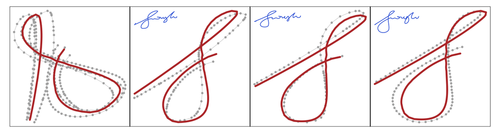

[figure not shown]

Let matrices $\mathbf{X}, \mathbf{Y} \in \mathbb{R}^{n \times p}$ record $n$ points on the two shapes. Mathematically we consider the problem
$$\begin{eqnarray*}
\text{minimize}_{\beta, \mathbf{O}, \mu} \quad \|\mathbf{X} - (\beta \mathbf{Y} \mathbf{O} + \mathbf{1}_n \mu^T)\|_{\text{F}}^2,
\end{eqnarray*}$$
where $\beta > 0$ is a scaling factor, $\mathbf{O} \in \mathbb{R}^{p \times p}$ is an orthogonal matrix, and $\mu \in \mathbb{R}^{p}$ is a vector of shifts. Here $\|\mathbf{M}\|_{\text{F}}^2 = \sum_{i,j} m_{ij}^2$ is the squared Frobenius norm. Intuitively we want to rotate, stretch and shift the shape $\mathbf{Y}$ to match the shape $\mathbf{X}$ as much as possible.

1. Let $\bar{\mathbf{x}}$ and $\bar{\mathbf{y}}$ be the column mean vectors of the matrices and $\tilde{\mathbf{X}}$ and $\tilde{\mathbf{Y}}$ be the versions of these matrices centered by column means. Show that the solution $(\hat{\beta}, \hat{\mathbf{O}}, \hat{\mu})$ satisfies
   $$\begin{eqnarray*}
   \hat{\mu} = \bar{\mathbf{x}} - \hat{\beta} \cdot \hat{\mathbf{O}}^T \bar{\mathbf{y}}.
   \end{eqnarray*}$$
   Therefore we can center each matrix at its column centroid and then ignore the location completely.
2. Derive the solution to
   $$\begin{eqnarray*}
   \text{minimize}_{\beta, \mathbf{O}} \quad \|\tilde{\mathbf{X}} - \beta \tilde{\mathbf{Y}} \mathbf{O}\|_{\text{F}}^2
   \end{eqnarray*}$$
   using the SVD of $\tilde{\mathbf{Y}}^T \tilde{\mathbf{X}}$.

### Q15 ([Ridge regression](https://scikit-learn.org/stable/modules/generated/sklearn.linear_model.Ridge.html))

One popular regularization method in machine learning is the ridge regression, which estimates regression coefficients by minimizing a penalized least squares criterion
$$\begin{eqnarray*}
\frac 12 \| \mathbf{y} - \mathbf{X} \beta\|_2^2 + \frac{\lambda}{2} \|\beta\|_2^2.
\end{eqnarray*}$$
Here $\mathbf{y} \in \mathbb{R}^n$ and $\mathbf{X} \in \mathbb{R}^{n \times p}$ are fixed data. $\boldsymbol{\beta} \in \mathbb{R}^p$ are the regression coefficients to be estimated.

1. Show that, regardless the shape of $\mathbf{X}$, there is always a unique global minimum for any $\lambda>0$ and the ridge solution is given by
   $$\begin{eqnarray*}
   \widehat{\boldsymbol{\beta}}(\lambda) = (\mathbf{X}^T \mathbf{X} + \lambda \mathbf{I})^{-1} \mathbf{X}^T \mathbf{y}.
   \end{eqnarray*}$$
2. Express ridge solution $\widehat{\boldsymbol{\beta}}(\lambda)$ in terms of the singular value decomposition (SVD) of $\mathbf{X}$.
3. Show that (i) the $\ell_2$ norms of ridge solution $\|\widehat{\boldsymbol{\beta}}(\lambda)\|_2$ and corresponding fitted values $\|\widehat{\mathbf{y}} (\lambda)\|_2 = \|\mathbf{X} \widehat{\boldsymbol{\beta}}(\lambda)\|_2$ are non-increasing in $\lambda$ and (ii) the $\ell_2$ norm of the residual vector $\|\mathbf{y} - \widehat{\mathbf{y}}(\lambda)\|_2$ is non-decreasing in $\lambda$.
4. (**Optional**) Let’s address how to choose the optimal tuning parameter $\lambda$. Let $\widehat{\boldsymbol{\beta}}_k(\lambda)$ be the solution to the ridge problem
   $$\begin{eqnarray*}
   \text{minimize} \,\, \frac 12 \| \mathbf{y}_{-k} - \mathbf{X}_{-k} \boldsymbol{\beta}\|_2^2 + \frac{\lambda}{2} \|\beta\|_2^2,
   \end{eqnarray*}$$
   where $\mathbf{y}_{-k}$ and $\mathbf{X}_{-k}$ are the data with the $k$-th observation taken out. The optimal $\lambda$ can to chosen to minimize the cross-validation square error
   $$\begin{eqnarray*}
   C(\lambda) = \frac 1n \sum_{k=1}^n [y_k - \mathbf{x}_k^T \widehat{\boldsymbol{\beta}}_k(\lambda)]^2.
   \end{eqnarray*}$$
   However computing $n$ ridge solutions $\widehat{\boldsymbol{\beta}}_k(\lambda)$ is expensive. Show that, using SVD $\mathbf{X}=\mathbf{U} \Sigma \mathbf{V}^T$,
   $$\begin{eqnarray*}
   C(\lambda) = \frac 1n \sum_{k=1}^n \left[ \frac{y_k - \sum_{j=1}^r u_{kj} \tilde y_j \left( \frac{\sigma_j^2}{\sigma_j^2 + \lambda} \right)}{1 - \sum_{j=1}^r u_{kj}^2 \left( \frac{\sigma_j^2}{\sigma_j^2 + \lambda} \right)} \right]^2,
   \end{eqnarray*}$$
   where $\tilde{\mathbf{y}} = \mathbf{U}^T \mathbf{y}$. Therefore, in practice, we only need to do SVD of $\mathbf{X}$ and then find the optimal value $\lambda$ that minimizes the leave-one-out (LOO) cross-validation error.

### Q16 (**Optional**) ([Factor analysis](https://scikit-learn.org/stable/modules/generated/sklearn.decomposition.FactorAnalysis.html))

Let $\mathbf{y}_1, \ldots, \mathbf{y}_n \in \mathbb{R}^p$ be iid samples from a multivariate normal distribution $N(\mathbf{0}_p, \mathbf{F} \mathbf{F}' + \mathbf{D})$, where $\mathbf{F} \in \mathbb{R}^{p \times r}$ and $\mathbf{D} \in \mathbb{R}^{p \times p}$ is a diagonal matrix with positive entries. We estimate the factor matrix $\mathbf{F}$ and diagonal matrix $\mathbf{D}$ by maximizing the log-likelihood function
$$\ell(\mathbf{F}, \mathbf{D}) = - \frac n 2 \ln \det (\mathbf{F} \mathbf{F}' + \mathbf{D}) - \frac n2 \text{tr} \left[(\mathbf{F} \mathbf{F}' + \mathbf{D})^{-1} \mathbf{S} \right] - \frac{np}{2} \ln 2\pi,$$
where $\mathbf{S} = n^{-1} \sum_{i=1}^n \mathbf{y}_i \mathbf{y}_i'$.

1. We first show that, for fixed $\mathbf{D}$, we can find the maximizer $\mathbf{F}$ explicitly using SVD by the following steps.
   - Step 1: Take derivative with respect to $\mathbf{F}$ and set to 0 to obtain the first-order optimality condition.
   - Step 2: Reparameterize $\mathbf{H} = \mathbf{D}^{-1/2} \mathbf{F}$ and $\tilde{\mathbf{S}} = \mathbf{D}^{-1/2} \mathbf{S} \mathbf{D}^{-1/2}$, and express the first-order optimality condition in terms of $\mathbf{H}$ and $\tilde{\mathbf{S}}$.
   - Step 3: Let $\mathbf{H} = \mathbf{U} \boldsymbol{\Sigma} \mathbf{V}'$ be its SVD. Show that columns of $\mathbf{U}$ must be $r$ eigenvectors of $\tilde{\mathbf{S}}$.
   - Step 4: Identify which $r$ eigenvectors of $\tilde{\mathbf{S}}$ to use in $\mathbf{U}$ and then derive the solution to $\mathbf{F}$.
2. Show that, for fixed $\mathbf{F}$, we can find the maximizer $\mathbf{D}$ explicitly. (Hint: first-order optimality condition.)

Combining 1 and 2, a natural algorithm for finding the MLE of factor analysis model is to alternately update $\mathbf{F}$ and $\mathbf{D}$ until convergence.